# Импорты

```python
import pandas as pd
import scipy.stats as st
import numpy as np
import matplotlib.pyplot as plt
import seaborn as sns
import statsmodels.api as sm
```

# Обзор датасета

Датасете собрана статистика о баскетбольных матчах по сезонам, с 1999г по 2020г.

Данные

- Season - Сезон YYYY-YYYY
- Player - Имя игрока
- GP - сколько сыграно игр
- MIN - сколько минут играл игрок в этом сезоне
- 3PM - сколько сделано трехочковых
- height - Рост игрока

```python
df = pd.read_csv("/content/players.csv")[["Season", "Player", "GP", "MIN", "3PM", "height_cm"]]
df.head()
```

|  | Season | Player | GP | MIN | 3PM | height_cm |
| --- | --- | --- | --- | --- | --- | --- |
| 0 | 1999 - 2000 | Shaquille O'Neal | 79 | 3163.0 | 0 | 216.0 |
| 1 | 1999 - 2000 | Vince Carter | 82 | 3126.0 | 95 | 198.0 |
| 2 | 1999 - 2000 | Karl Malone | 82 | 2947.0 | 2 | 206.0 |
| 3 | 1999 - 2000 | Allen Iverson | 70 | 2853.0 | 89 | 183.0 |
| 4 | 1999 - 2000 | Gary Payton | 82 | 3425.0 | 177 | 193.0 |

Избавимся от пропусков, просто удалив их

```python
df.shape
```

```
(53949, 6)
```

```python
df.dropna(inplace=True)
df.shape
```

```
(53875, 6)
```

Итого, мы имеем четрые метрики:

- GP - сколько сыграно игр
- MIN - сколько минут играл игрок в этом сезоне
- 3PM - сколько сделано трехочковых
- height - Рост игрока

Разобьем наш датасет на сегменты по периодам:

- 1999 - 2006
- 2007 - 2013
- 2014 - 2019

```python
df["Season"] = df["Season"].str.slice(stop=4).astype(int)
```

```python
before2006 = (
    df
    .loc[df['Season'] <= 2006]
    .groupby('Player')["GP", "MIN", "3PM", "height_cm"]
    .agg({'GP': 'sum', 'MIN': 'sum', "3PM": 'sum', "height_cm": 'mean'})
)

before2013 = (
    df
    .loc[(df['Season'] > 2006) & (df['Season'] <= 2013)]
    .groupby('Player')["GP", "MIN", "3PM", "height_cm"]
    .agg({'GP': 'sum', 'MIN': 'sum', "3PM": 'sum', "height_cm": 'mean'})
)

before2020 = (
    df
    .loc[df['Season'] > 2013]
    .groupby('Player')["GP", "MIN", "3PM", "height_cm"]
    .agg({'GP': 'sum', 'MIN': 'sum', "3PM": 'sum', "height_cm": 'mean'})
)
```

```python
print("before2006 size:", before2006.shape)
print("before2013 size:", before2013.shape)
print("before2020 size:", before2020.shape)
```

```
before2006 size: (2112, 4)
before2013 size: (6497, 4)
before2020 size: (10732, 4)
```

Сгенерируем всевозможные пары сегментов

```python
segments = {
            "before2006": before2006,
            "before2013": before2013,
            "before2020": before2020
            }
pairs = [(a, b) for idx, a in enumerate(list(segments.keys())) for b in list(segments.keys())[idx + 1:]]
```

# Однородность распределений

## Непрерывное распределение

Для проверки однородности выборок воспользуемся *критерием Колмогорова*.

Проверем однородность распределения роста игроков в различных временных сегментах.

```python
for pair in pairs:
        pv = st.ks_2samp(segments[pair[0]]["height_cm"].values,
                         segments[pair[1]]["height_cm"].values).pvalue
        print(*pair, f'metric: height_cm', f"pvalue: {pv}")
```

```
before2006 before2013 metric: height_cm pvalue: 3.88089359818241e-14
before2006 before2020 metric: height_cm pvalue: 4.3550338128262107e-26
before2013 before2020 metric: height_cm pvalue: 0.00019010185178221936
```

Сравним распределения визуально

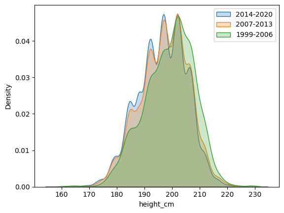

```python
sns.kdeplot(before2020["height_cm"], label="2014-2020", fill=True)
sns.kdeplot(before2013["height_cm"], label="2007-2013", fill=True)
sns.kdeplot(before2006["height_cm"],  label="1999-2006",fill=True)
plt.legend()
```

Критерий Колмогорова показал, что распределение роста различно во всех временных сегментах.

## Дискретное распределение

Для проверки однородности распределения количества забитых трехочковых воспользуемся критерием Манна-Уитни. Критерий Пирсона в этом случае использовать затруднительно из-за различия размерностей выборок

```python
for pair in pairs:
        pv = st.mannwhitneyu(segments[pair[0]]["3PM"].values,
                             segments[pair[1]]["3PM"].values).pvalue
        print(*pair, f'metric: 3PM', f"pvalue: {pv}")
```

```
before2006 before2013 metric: 3PM pvalue: 8.334462491948964e-05
before2006 before2020 metric: 3PM pvalue: 2.0474616440189764e-07
before2013 before2020 metric: 3PM pvalue: 0.05176335578781351
```

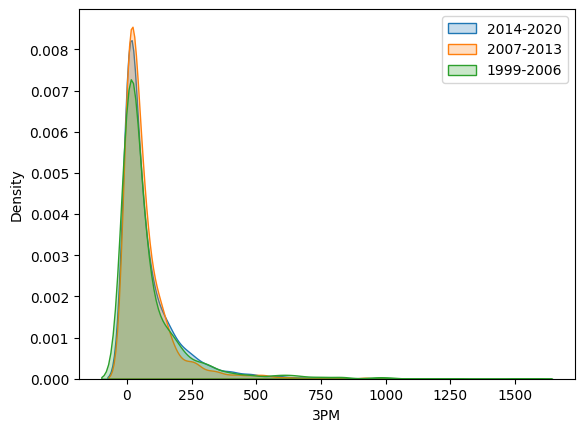

```python
sns.kdeplot(before2020["3PM"].sample(2112), label="2014-2020", fill=True)
sns.kdeplot(before2013["3PM"].sample(2112), label="2007-2013", fill=True)
sns.kdeplot(before2006["3PM"].sample(2112),  label="1999-2006",fill=True)
plt.legend()
```

В случае всех трех сегментов гипотеза об однорости распределений количества трехочковых отвергается, кроме двух последних сегментов, значение pvalue больше 0.05, значит гипотезу об однородности выборок не отвергаем

# Равенство медиан

## Непрерывное распределение

Проверим гипотезу о равенстве медиан для распределения роста в трех сегментах. Мы не можем применить критерий Манна-Уитни, так как распределения выборок не однородны, воспользуемся критерием Уилкоксона, при этом мы должны понимать, что выборки зависимые (в разных сегментах имеются одни и те же игроки) и разного размера. Будем брать подвыборки и считать среднюю ошибку первого рода.

```python
from tqdm import tqdm
def wilc(data1, data2):
    n = min(data1.shape[0], data2.shape[0])
    c = 0
    for i in range(1000):
        c += st.wilcoxon(
            data1.sample(n, replace=False),
            data2.sample(n, replace=False)
            ).pvalue < 0.05

    return c / 1000
```

```python
for pair in pairs:
        pv = wilc(
            segments[pair[0]]["height_cm"],
            segments[pair[1]]["height_cm"]
            )
        print(*pair, f'metric: height_cm', f"pvalue: {pv}")
        print("---")
```

```
before2006 before2013 metric: height_cm pvalue: 1.0
---
before2006 before2020 metric: height_cm pvalue: 1.0
---
before2013 before2020 metric: height_cm pvalue: 1.0
---
```

## Дискретное распределение

Для проверки равенства медиан распределения кол-ва трехочковых воспользуемся критерием Уилкоксона.

Мы знаем, что распределения сегментов 2007-2013 гг. и 2014-2020 гг. являются однородными.

Для них применим критерий Манна-Уитни, а для остальных воспользуемся критерием Уилкоксона. здесь такие же ограничения как и в проверке гипотез для роста игроков: выборки зависимые (в разных сегментах имеются одни и те же игроки) и разного размера.

```python
for pair in pairs:
        pv = wilc(
            segments[pair[0]]["3PM"],
            segments[pair[1]]["3PM"]
            )
        print(*pair, f'metric: 3PM', f"pvalue: {pv}")
        print("---")
```

```
before2006 before2013 metric: 3PM pvalue: 0.007
---
before2006 before2020 metric: 3PM pvalue: 0.705
---
before2013 before2020 metric: 3PM pvalue: 0.996
---
```

```python
st.mannwhitneyu(before2013["3PM"], before2020["3PM"])
```

```
MannwhitneyuResult(statistic=34247700.5, pvalue=0.05176335578781351)
```

# Бутстрап

Перед нами стоит задача: проверить результаты гипотез об однородности распределений с помощью бутстрапа.

```python
def bootstrap_confidence_interval(sample, stat, alpha=0.05):
    """
    Стоит эфронов 1 - alpha доверительный интервал для выбранной статистики stat
    """
    n = sample.shape[0] // 2
    distribution_lst = []
    for _ in range(100):
        a_ = np.random.choice(sample, size=n, replace=True)
        distribution_lst.append(stat(a_))

    return np.percentile(distribution_lst, q=[alpha / 2 * 100, (1 - alpha / 2) * 100])
```

## Медиана роста игроков

```python
bootstrap_confidence_interval(before2006["height_cm"],  np.median)
```

```
array([198., 201.])
```

```python
bootstrap_confidence_interval(before2013["height_cm"],  np.median)
```

```
array([198., 198.])
```

```python
bootstrap_confidence_interval(before2020["height_cm"],  np.median)
```

```
array([196., 198.])
```

Доверительные интервалы согласуются с полученными результатами

## Медиана количества трехочковых

```python
bootstrap_confidence_interval(before2006["3PM"],  np.median)
```

```
array([24., 35.])
```

```python
bootstrap_confidence_interval(before2013["3PM"],  np.median)
```

```
array([34., 39.])
```

```python
bootstrap_confidence_interval(before2020["3PM"],  np.median)
```

```
array([34., 39.])
```

Результаты во многом схожи с полученными значениями pvalue.

# Задание 3

Попробуем применить бутстрап для проверки однородности распределений следующим образом: для непрерывных распределений будем пользоваться критерием Колмогорова, а для диспректных - Манна-Уитни.

Для каждого испытания будем брать случайную подвыборку из обоих выборок и проверять на однородность, в качестве итогового ответа выведем среднее значение pvalue

## Непрерывные распределения

```python
def bootstrap_kolmogorov(data1, data2):
    """
    Возвращает среднее значение pvalue
    основанное на проверки однородсти двух выборок критерием Колмогорова
    """
    n = min(data1.shape[0], data2.shape[0])
    pvalues = []
    for _ in range(100):
        pv = st.ks_2samp(data1.sample(n).values,
                         data2.sample(n).values
                         ).pvalue
        pvalues.append(pv)

    return sum(pvalues) / len(pvalues)
```

```python
for pair in pairs:
        pv = bootstrap_kolmogorov(segments[pair[0]]["height_cm"],
                         segments[pair[1]]["height_cm"])
        print(*pair, f'metric: height_cm', f"pvalue: {pv}")
```

```
before2006 before2013 metric: height_cm pvalue: 2.550444012366385e-07
before2006 before2020 metric: height_cm pvalue: 3.830413576937051e-12
before2013 before2020 metric: height_cm pvalue: 0.002757489511971402
```

Видим, что результаты соотносятся с раннее проведенными тестами

## Дискретное распределение

```python
def bootstrap_mannwhitney(data1, data2):
    """
    Возвращает среднее значение pvalue
    основанное на проверки однородсти двух выборок критерием Манна-Уитни
    """
    n = min(data1.shape[0], data2.shape[0])
    pvalues = []
    for _ in range(100):
        pv = st.mannwhitneyu(data1.sample(n).values,
                         data2.sample(n).values
                         ).pvalue
        pvalues.append(pv)

    return sum(pvalues) / len(pvalues)
```

```python
for pair in pairs:
        pv = bootstrap_mannwhitney(segments[pair[0]]["3PM"],
                         segments[pair[1]]["3PM"])
        print(*pair, f'metric: 3PM', f"pvalue: {pv}")
```

```
before2006 before2013 metric: 3PM pvalue: 0.006237813717666986
before2006 before2020 metric: 3PM pvalue: 0.0004808536126065329
before2013 before2020 metric: 3PM pvalue: 0.1058599446782055
```

Результаты снова соотносятся с ранее проведенными тестами.

## Попробуем проверить однородность выборок построив доверительные интервалы для начальных моментов разности их подвыборок

```python
def moment(data, k=1):
    return np.power(data, k) / data.shape[0]
```

```python
def bootstrap_confidence_interval_2_samples(data1, data2, alpha=0.05, k=1):
    """
    Стоит эфронов 1 - alpha доверительный интервал для моментов порядка k
    """
    n = min(data1.shape[0] // 2, data2.shape[0] // 2)
    distribution_lst = []
    for _ in range(100):
        a_ = (data1.sample(n).values - data2.sample(n).values)
        distribution_lst.append(moment(a_, k))

    return np.percentile(distribution_lst, q=[alpha / 2 * 100, (1 - alpha / 2) * 100])
```

Построим доверительные интервалы для начальных моментов порядков 1, 2, 3 для проверки однородности подвыборок роста игроков.

```python
for pair in pairs:
        interval = bootstrap_confidence_interval_2_samples(
                                                segments[pair[0]]["height_cm"],
                                                segments[pair[1]]["height_cm"])
        print(*pair, f'metric: height_cm', f"interval: {interval}")
```

```
before2006 before2013 metric: height_cm interval: [-0.0217803   0.02462121]
before2006 before2020 metric: height_cm interval: [-0.0217803   0.02462121]
before2013 before2020 metric: height_cm interval: [-0.00708128  0.00769704]
```

```python
for pair in pairs:
        interval = bootstrap_confidence_interval_2_samples(
                                                segments[pair[0]]["height_cm"],
                                                segments[pair[1]]["height_cm"],
                                                k=2)
        print(*pair, f'metric: height_cm', f"interval: {interval}")
```

```
before2006 before2013 metric: height_cm interval: [0.         0.74242424]
before2006 before2020 metric: height_cm interval: [0.         0.74242424]
before2013 before2020 metric: height_cm interval: [0.         0.24137931]
```

```python
for pair in pairs:
        interval = bootstrap_confidence_interval_2_samples(
                                                segments[pair[0]]["height_cm"],
                                                segments[pair[1]]["height_cm"],
                                                k=3)
        print(*pair, f'metric: height_cm', f"interval: {interval}")
```

```
before2006 before2013 metric: height_cm interval: [-11.5217803   16.64393939]
before2006 before2020 metric: height_cm interval: [-11.5217803   16.64393939]
before2013 before2020 metric: height_cm interval: [-3.74599754  4.81065271]
```

Можем заметить, что дверительные интервалы для моментов нечетных порядков пересекают точку 0, а также что доверительные интервалы для моментов второго порядка довольно узкие, особенно для сегмента 2007 - 2013 и 2014 - 2020 гг.

Эти результаты ставят под сомнение результаты полученные раннеее.

## Мнение

По моему мнению бутстрап довольно мощный способ проверки статистических гипотез относительно каких либо параметров распределения. Однако не совсем понятно как его можно использовать для проверки гипотез об однородности выборок. Также бустрап очень хорош, когда распределение выборок не подходит для статистических тестов. На моих данных бутстрапом пришлось воспользоваться только для подтверждения полученных выводов о равенствах медиан, но если бы данные не подходили под требования критериев, то гораздо более адекватными методом проверки гипотез оказался бы бутстрап.

Для проверки гипотез о распределении выборки или однородности двух выборок я точно буду пользоваться статистическими критериями, а не эвристиками для проверки этих гипотез.